# Cover cropping enhances soil microbial biomass and affects microbial community structure: A meta-analysis - ScienceDirect

## Outline

[figure not shown]

[figure not shown]

[figure not shown]

[figure not shown]

[figure not shown]

## [Geoderma](https://www.sciencedirect.com/science/journal/00167061)

[Volume 381](https://www.sciencedirect.com/science/journal/00167061/381/supp/C), 1 January 2021, 114696

# Cover cropping enhances soil microbial biomass and affects microbial community structure: A *meta*-analysis

[IhsanMuhammad<sup>a</sup><sup>b</sup>](https://www.sciencedirect.com/science/article/pii/S0016706120309095#!)[JunWang<sup>a</sup><sup>b</sup>](https://www.sciencedirect.com/science/article/pii/S0016706120309095#!)[Upendra M.Sainju<sup>c</sup>](https://www.sciencedirect.com/science/article/pii/S0016706120309095#!)[ShaohongZhang<sup>b</sup>](https://www.sciencedirect.com/science/article/pii/S0016706120309095#!)[FazhuZhao<sup>a</sup><sup>b</sup>](https://www.sciencedirect.com/science/article/pii/S0016706120309095#!)[AhmadKhan<sup>d</sup>](https://www.sciencedirect.com/science/article/pii/S0016706120309095#!)

https://doi.org/10.1016/j.geoderma.2020.114696[Get rights and content](https://s100.copyright.com/AppDispatchServlet?publisherName=ELS&contentID=S0016706120309095&orderBeanReset=true)

## Highlights

**•**

Cover crops overall increased MBC, MBN and PLFA by 24–51% compared to fallow.

**•**

Cover crops favored growth of fungi more than bacteria.

**•**

Cover crop effect on microbial structure varied with species and residue management.

**•**

Cover crop effect on microbial properties varied with soil and climatic conditions.

**•**

Cover crops enhance biological soil health due to microbial community abundance.

## Keywords

Soil organic carbon

Soil microbial

Bacteria

Fungi

## 1. Introduction

Cover cropping, a conservation practice to reduce soil erosion, has been widely adopted by producers to increase soil organic matter (Poeplau and Don, 2015) enhance nitrogen (N) cycling (Sainju et al., 2003), improve soil structure (Blanco-Canqui et al., 2011), and reduce pest infection and N leaching compared to no cover crop (Lupwayi et al., 2012, Daryanto et al., 2018). The improvement in soil and environmental quality with cover crop compared to no cover crop was primarily due to the addition of above- and belowground residue in the soil. As decomposition of crop residue is controlled by soil biota, information on the effects of cover crop on soil microbial biomass, community structure and diversity is needed to understand their relationship on nutrient cycling, C sequestration, and soil health (Frasier et al., 2016).

Cover crop species and management of residue affect microbial abundance and community structure due to difference in quality and quantity of residue returned to the soil (Martinez-Garcia et al., 2018). Generally, legume cover crops supply more N from biological N fixation to succeeding crops than nonlegume or no cover crop (Gabriel et al., 2012). In contrast, nonlegume cover crops can be more effective in enhancing soil organic matter and reducing N leaching due to their greater biomass production (Sainju et al., 2002, Sainju et al., 2003). Sainju et al. (2007) reported that nonlegume cover crops increased microbial biomass C (MBC) compared to legume cover crops due to higher biomass yield and C content, but legume and mixed (legume + nonlegume) cover crops increased soil respiration compared to nonlegume cover crops. However, Wang et al. (2007) found that cover cropping with cowpea (*Vigna unguiculata* L.) had a similar MBC compared to that with sorghum sudangrass (*Sorghum bicolor.* L.*, var. sudanense*). Others (Lehman et al., 2015, Sainju et al., 2003) found that legume cover crops increased MBN compared to no cover crop. The addition of high-quality residue from cover crops, such residue with high N content or low C/N ratio, favors bacterial dominance, whereas low-quality residue favors fungal growth (Bossuyt et al., 2001, Millar et al., 2004, Kramer et al., 2012). Both fungal and bacterial populations increased with nonlegume compared to legume or no cover crop (Patkowska et al., 2016). Cover crop residue management practices, such as residue incorporation into the soil surface placement, or removal from the soil also had significant impact on soil microbial diversity (Nevins et al., 2018).

Microbial community abundance and structure are highly regulated by soil properties, such as pH, C/N ratio, aeration (Drury et al., 1991, Fierer and Jackson, 2006, Peregrina et al., 2014, Yang et al., 2017), and soil temperature and water content (Kong and Six, 2012, Muhammad et al., 2019). Brennan and Acosta-Martinez (2017) found that cover crops increased MBC compared to no cover crop in sandy and loamy soils. Njeru et al. (2014); Njeru et al. (2015) reported that cover cropping improved arbuscular-mycorrhizal fungi (AMF) colonization compared to no cover cropping under organic maize (*Zea mays* L.) production in Italy. Reed-Jones et al. (2016) found that the effect of cover crop on some bacteria varied with soil temperature and water content. In order to synthesize the existing knowledge about the effect of cover crop on microbial community structure and abundance and identify driving factors for observed differences, a systematic study to assess the overall impact of cover crop on microbial parameters is needed.

Meta-analysis is a useful tool to pool together the data from various regions with different soil and climatic conditions and management practices using effect size from individual studies (Hungate et al., 2009, Borenstein et al., 2011). In this study, a *meta*-analysis based on the data available in the literature was conducted to synthesize the overall effect of cover cropping, cover crop species, and residue management practices on soil microbial community abundance and structure under different soil and climatic conditions. Soil microbial community abundance was assessed via MBC, microbial biomass nitrogen (MBN), and phospholipid-derived fatty acids (PLFA), and community structure via PLFA patterns as bacteria, fungi, actinomycetes, and AMF. We hypothesized that (1) cover cropping would have an overall positive effect on soil microbial community abundance and structure compared to no cover cropping, (2) such effect will vary with cover crop species and residue management practice, and (3) soil and climatic conditions of various regions will alter the effect of cover crop on soil microbial biomass and community abundance.

## 2. Materials and methods

### 2.1. Data collection

To quantify the effect of cover crop on soil microbial community abundance and structure, a search on these parameters was carried out in peer review journals from 1990 to 2019 in Web of Science and Google Scholar. Keywords included PLFA, MBC, MBN, bacteria, fungi, and AMF as affected by cover crop, green manure or catch crop. About 169 publications were collected and screened using the following criteria for further data collection:

**i.**

Experiments should be conducted in the field and data for legume, nonlegume, and/or mixed cover crops should be compared with no cover crop (fallow) in a region with similar soil and climatic conditions. Studies with no control treatment (or fallow) were discarded.

**ii.**

Data comparing the effect of legume, nonlegume, and/or mixed (legume + nonlegume + oilseed crops) cover crops on soil microbial properties were selected.

**iii.**

Treatments should be replicated at least three times and mean values shown with standard deviation (SD) or standard error (SE).

**iv.**

Where different rates of fertilization were applied to crops following cover crops, only treatments with the recommended fertilizer rates based on the regions were selected. If different fertilizer types were used to supply nutrients, mean values of nutrients among fertilizer types were calculated and used for the study.

Based on these criteria, about 1824 pairwise observations from 81 publications were finally included for *meta*-analysis. These studies encompassed over 21 countries (Fig. 1). The annual mean air temperature and annual precipitation of the experimental sites were recorded for each study. The pH, initial organic C (SOCi), and texture of the surface soil were also recorded. In cases where the information was not found in the publications, an online search engine (https://www.whatsmygps.com) was used to determine the latitude and longitude of experimental sites and the data for soil properties and climatic conditions. The geographical information of experimental sites, soil properties and climatic conditions for each study were summarized in Appendix A.

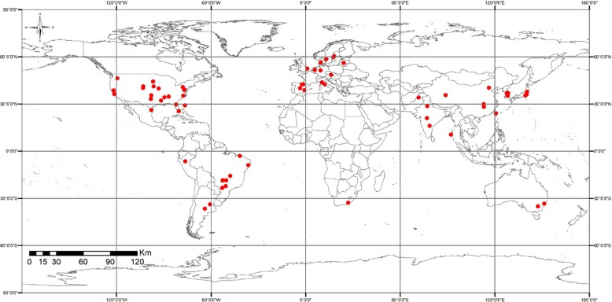

Fig. 1. Distribution of 81 experimental sites around the world where data were collected for the *meta*-analysis.

During the *meta*-analysis, different cover crops in rotations with succeeding crops from a site were handled as individual comparison. Data for PLFA, MBC, MBN, total bacteria, total fungi, gram positive and negative bacteria, actinomycetes, AMF, AMF root colonization and spore density were extracted from the respective literature. A software of GetData graph digitizer 2.26 (http://getdata-graph-digitizer.com/index.php) was used to extract the data from the figures. If SEs were reported with means, the following equation was used to calculate the SD.(1)$SD=SE×n$

Where n is the number of replicates.

We extracted 134, 329, and 149 paired observations (cover crop *vs.* no cover crop) from the literature for PLFA, MBC, and MBN, respectively, to compare the response of microbial community abundance to cover crops. About 111, 272, and 130 pairwise observations of total bacteria, total fungi, and fungi/bacteria ratio, respectively, were collected for the microbial community structure analysis. About 127, 122, and 184 paired observations for gram-positive, gram-negative bacteria, and actinomycete, respectively, were collected for bacteria groups, and 78, 159, and 29 in AMF, AMF root colonization and AMF spore density, respectively, for soil fungi groups.

### 2.2. Variance estimators and weighting function

One of the challenges in conducting a systematic analysis is reporting the complete outcome of variance estimators and weighting functions (Furukawa et al., 2006, Wiebe et al., 2006). In this analysis, we estimated the effect size and related inferences using the weighting method (Hungate et al., 2009), based on the inverse of pooled variance (Van Groenigen et al., 2011). In studies where no variances were reported, the coefficient of variation (CV) was calculated using the following equation.(2)$CV=SDMMm×100$

Where SD<sub>M</sub> and M<sub>m</sub> are SD and mean, respectively. When SD was missing, it was calculated as:(3)$SDmissing=CV×M100$

Where CV is coefficient of variance, and M is the mean.

### 2.3. Data analysis

The effect of cover crop on microbial variables was calculated using the response ratio (RR) as the effect size which is calculated as the natural log of ratio of treatments with and without cover crop (Hedges et al., 1999) as follows:(4)$RR=LnXccXncc=LnXcc-LnXncc$

Where X<sub>cc</sub> and X<sub>ncc</sub> are arithmetic mean of the microbial variables in cover crop (CC) and no cover crop treatments (NCC), respectively. The natural log ratio confirms that changes in the numerator and denominator are affected equally. If the distributions of X<sub>cc</sub> and X<sub>ncc</sub> are normal and X<sub>ncc</sub> is unlikely to be negative, the RR will be approximately normally distributed, with a mean equal to the true log response ratio (Gurevitch, 1993). Furthermore, the error variance of the RR (V<sub>LnRR</sub>) for each study was calculated using the following equation (Hedges et al., 1999).(5)$VLnRR=Scc2nccXcc2+Sncc2nnccXncc2$

Where S<sub>cc</sub> and S<sub>ncc</sub> are SD, n<sub>cc</sub> and n<sub>ncc</sub> are number of replications, and X<sub>cc</sub> and X<sub>ncc</sub> are means for cover crop and no cover crop treatments, respectively.

The random effect model with 95% confidence interval using the reciprocal of the variance (V) and the weight (W) for each RR was calculated as (Borenstein et al., 2011):(6)$W=1/V$

The overall mean response ratio (RR<sub>E++</sub>) for individual cover crop treatment was calculated as:(7)$RRE++=∑i=1n∑j=1mWijRRij∑i=1n∑j=1mWij$

Where “n” and “m” are the number of treatments and comparisons for each microbial variable, respectively. The standard error of RR<sub>E++</sub> was calculated as:(8)$SERRE++=1∑i=1n∑j=1mWij$

To analyze the effect of cover crop on microbial variables, random model MetaWin 2.1 (Sinaure Associate Inc., Sunderland, USA) was used to compute the mean effect size at bias-based bootstrap 95% confidence intervals (CIs). The effect of cover crop was considered significant if the 95% CIs did not overlap the vertical zero line.

The effect of cover crop species and residue management was also examined on soil microbial community abundance and structure. Oilseed cover crops were treated as nonlegumes. Residue management practices included incorporation into the soil (Incorporated), placement at the soil surface (Surface), and removal from the soil (Removal). The random effect models allow comparisons among both studies and groups. Statistical results reported the total heterogeneity of RR (95% CIs) among studies (*Q<sub>T</sub>*), between studies (*Q<sub>B</sub>*) and within studies (*Q<sub>W</sub>*) (Hedges and Olkin, 1985). We also calculated the I-square index by dividing the difference between variance and its degrees of freedom (n−1) by total variance itself (Huedo-Medina et al., 2006). Greater *I<sup>2</sup>* values than 25% or 50% indicate a significant amount of heterogeneity. Data heterogeneities for target variables were summarized in Table S1 in the Supplementary information. To determine how cover crop affect soil microbial variables due to changes in soil and climatic conditions, regression analysis of RR to soil pH, SOCi and C/N ratio as well as annual mean air temperature and precipitation were conducted using the Origin 2018 software based on single observation (OriginLab Corporation, USA). The publication bias was tested with Rosenthal’s fail-safe number using MetaWin 2.1 (Table S2). Greater fail-safe number than 5n + 10, where n is the observations’ number, indicates no publication bias (Rosenthal, 1991, Dieleman and Janssens, 2011).

## 3. Results

### 3.1. Data heterogeneity and publication bias

Our *meta*-analysis involving 1824 pairwise comparisons from 81 studies extending 21 countries showed that observations for MBC, MBN, and PLFA were different and data for most microbial variables exhibited a high heterogeneity among cover crop species, residue management practices, and soil textures, as characterized with great values of *Q<sub>T</sub>* and *I<sup>2</sup>* (Table S1). The great fail-safe numbers for all target variables indicate no publication bias (Table S2). These suggest that the data quality met the standard for *meta*-analysis.

### 3.2. Effect of cover crop on soil microbial community abundance

Cover crop overall increased PLFA, MBC, and MBN by 24, 40, and 51%, respectively, compared to no cover crop (*P* ≤ 0.05, Fig. 2). The categorical *meta*-analyses revealed that PLFA and MBC increased with legume and nonlegume compared to mixed cover crops (*P* ≤ 0.05). The response for MBN, however, was inconsistent among cover crop species (Table S1). The RRs of PLFA, MBC and MBN was also affected by cover crop residue management practices. Incorporation of cover crop residue into the soil increased PLFA compared to surface placement (*P* ≤ 0.05). Removal of cover crop residue reduced MBN compared to residue incorporation or surface placement.

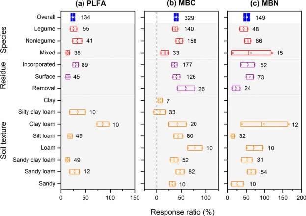

Fig. 2. Mean response ratio of cover crops compared to no cover crop and bootstrapped 95% confidence intervals (horizontal box) for total phospholipid-derived fatty acid (PLFA) and microbial biomass C and N (MBC and MBN) affected by cover crop species, residue management practices and soil textures. The vertical line (RR = 0) indicates no difference between cover cropping and no cover cropping systems. Numbers following the box indicate the number of observations for comparison.

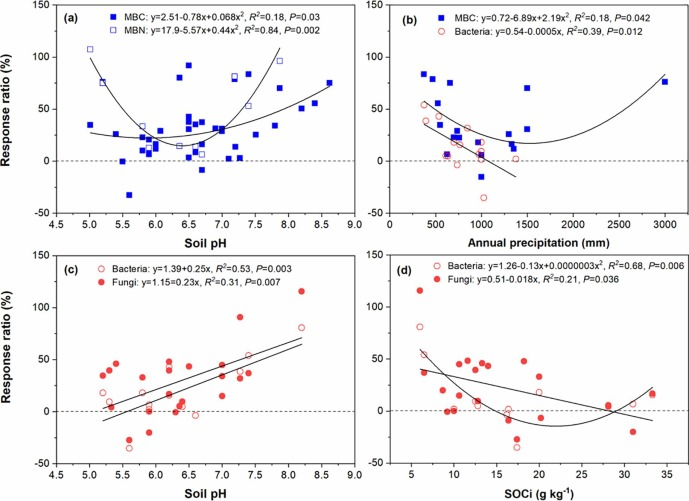

Fig. 3. Relationships between the response ratio of cover crop compared to no cover crop and soil pH, initial organic C (SOCi), and annual precipitation. The horizontal dash line (RR = 0) indicates no difference between cover cropping and no cover cropping systems.

### 3.3. Effect of cover crop on soil total bacteria, total fungi, and the fungi/bacteria ratio

Cover crops increased total bacteria by 15% and total fungi by 19% compared to no cover crops (*P* ≤ 0.05, Fig. 4a and b). Increases for total bacteria and fungi for legume cover crops were 23 and 16% and for nonlegume cover crops were 10 and 26%, respectively. Such differences, however, were not significant for mixed cover crops. The RR of cover crop for fungi/bacteria ratio was positive for all cover crop species (Fig. 4c). Incorporation of cover crop residue into the soil increased total bacteria compared to surface placement of the residue or removal from the soil (*P* ≤ 0.05), but residue management has no effect on RR of cover crop on total fungi, although all residue management practices showed positive effect. Residue incorporation enhanced the fungi/bacteria ratio compared to residue removal.

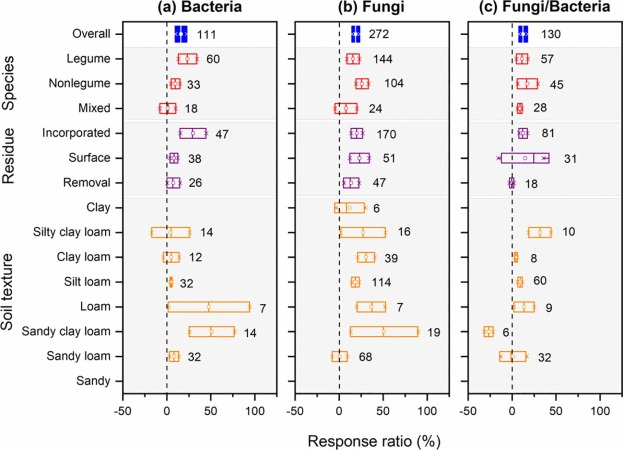

Fig. 4. Mean response ratio of cover crops compared to no cover crop and bootstrapped 95% confidence interval (horizontal box) for total bacteria, total fungi and the fungi/bacteria ratio affected by cover crop species, residue management practices and soil textures. The vertical line (RR = 0) indicates no difference between cover cropping and no cover cropping systems. Numbers following the box indicate the number of observations for comparison.

### 3.4. Effect of cover crop on soil gram-positive and -negative bacteria and actinomycete

Cover crop overall increased soil gram-positive and -negative bacteria and actinomycete by 17, 11, and 23%, respectively, compared to no cover crop (*P* ≤ 0.05, Fig. 5). The categorical *meta*-analyses showed that the effects of cover crops on the groups of gram-positive and -negative bacteria were not dependent on cover crop type or residue management practices, while the RR of actinomycete was greater with legume than nonlegume or mixed and with nonlegume than mixed cover crops. Mixture of legume and nonlegume cover crops had a neutral effect on actinomycete. Cover crop residue management practices did not affect the RR of actinomycete to cover crops. The RR of cover crop for actinomycete was significantly higher in sandy clay loam followed by clay loam than silt loam and sandy loam soils (*P* ≤ 0.05). The RRs of gram-positive and gram-negative bacteria and actinomycete were not correlated to soil pH, SOCi or annual precipitation and air temperature (Data not shown).

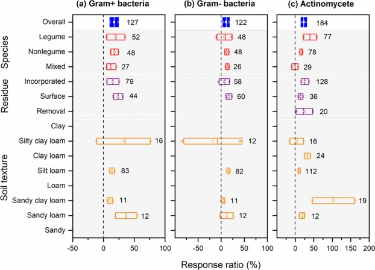

Fig. 5. Mean response ratio of cover crop compared to no cover crop for gram-positive (+) and negative (−) bacteria and actinomycete with bootstrapped 95% confidence intervals (horizontal box) affected by cover crop species, residue management practices and soil textures. The vertical line (RR = 0) indicates no difference between cover cropping and no cover cropping systems. Numbers following the box indicate the number of observations for comparison.

### 3.5. Effect of cover crop on arbuscular mycorrhizal fungi

Compared to no cover crops, cover crops overall increased AMF, AMF root colonization and AMF spore density by 26%, 13, and 47% (*P* ≤ 0.05, Fig. 6), respectively. The categorial analysis showed that the effects of cover crops on AMF and AMF root colonization and spore density were not dependent with cover crop types but varied with residue management practices. Surface-placed residue increased AMF compared to incorporated residue. In contrast, incorporated residue increased AMF root colonization and spore density compared to surface placed residue or residue removal. No significant correlations to soil pH, SOCi or annual precipitation and air temperature were found for AMF, AMF root colonization or AMF spore density (Data not shown).

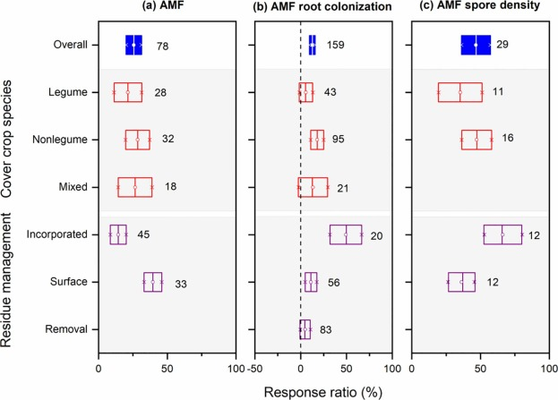

Fig. 6. Mean response ratio of cover crops compared to no cover crop for arbuscular mycorrhizal fungi (AMF), AMF root colonization and spore abundance and with bootstrapped 95% confidence intervals (horizontal box) affected by cover crop species and residue management practices. The vertical line (RR = 0) indicates no difference between cover cropping and no cover cropping systems. Numbers following the box indicate the number of observations for comparison.

## 4. Discussion

### 4.1. Soil microbial community abundance and structure

The positive effect of cover crop on microbial parameters compared to no cover crop clearly confirmed our first hypothesis that cover crop enhanced soil microbial community abundance and structure. The increases in PLFA, MBC and MBN with cover crops were probably due to enhanced C and N inputs from above- and below-ground cover crops residue (Chavarría et al., 2016, Schmidt et al., 2019). These inputs probably increase substrate availability for soil microbes, stimulating their growth and biomass. Considering the importance of soil microbes in maintaining soil health (Lehman et al., 2015), our findings suggest that cover crops can enhance biological soil health by stimulating soil microbial community abundance compared to no cover crop.

Although cover crops enhanced the growth of total bacteria and fungi, the positive RR of the fungi/ bacteria ratio (Fig. 4c) suggests that fungi responded to cover crops more than bacteria. Greater fungi/bacteria ratio with than without cover crop has been reported by some researchers (Nakamoto et al., 2012, Martinez-Garcia et al., 2018, Schmidt et al., 2019). Sanz-Cobena et al. (2014) found that additional input from cover crop residues increased the growth of fungi more than bacteria, as soil fungi are more sensitive to cover crop than bacteria (Schmidt et al., 2019). Numerous researchers (Kabir and Koide, 2002, White and Weil, 2010, Lehman et al., 2012, Njeru et al., 2015, Brennan and Acosta-Martinez, 2017) have reported that cover crops enhanced AMF growth which increased P availability and abiotic stress tolerance, suppress the infection of pathogens, and promote crop yields compared to no cover crop. Benitez et al. (2016) found that stimulation of AMF by cover crop improved soil fertility and crop yield.

### 4.2. Impacts of cover crop species and residue management practice

The varying effect with legume, nonlegume and mixed cover crops on soil microbial community abundance and structure can be explained by the quality and quantity of cover crop residue returned to the soil (Frasier et al., 2016, Bacq-Labreuil et al., 2019). Nonlegume cover crops generally produce greater above and belowground biomass, increase C supply, and have higher C/N ratio than legume cover crops (Kuo et al., 1997, Sainju et al., 2007). In contrast, legume cover crops fix N from the atmosphere, increase N supply to succeeding crops due to higher residue N concentration, and have lower C/N ratio than nonlegume cover crops (Kuo et al., 1997, Sainju et al., 2003). Although not significant, the slightly greater PLFA, MBC, and MBN with nonlegume than legume cover crop (Fig. 2) suggests that increased C substrate availability from enhanced cover crop biomass input probably increased microbial abundance and communities with nonlegume cover crop. Several researchers (Sainju et al., 2003, Sainju et al., 2007, Mbuthia et al., 2015, Muhammad et al., 2019) observed that nonlegume cover crops increased MBC and soil respiration, but legume cover crops increased MBN compared to no cover crop. The increased MBN with nonlegume than legume cover crop in this *meta*-analysis, however, was in disagreement with the results found by above researchers. In contrast, greater actinomycetes with legume than nonlegume cover crops (Fig. 5) suggests that these microorganisms thrive better in the N-rich environment. The reverse was true with fungi, which thrive better in the C-rich environment with nonlegume cover crops. The different responses of bacteria and fungi to legume and nonlegume cover crops have been well documented in the literature (Nakamoto et al., 2012, Frasier et al., 2016, Brennan and Acosta-Martinez, 2017). Fungi promote better in decomposing low quality residue, such as those of nonlegume cover crops, while bacteria favor decomposition of high-quality residue, such as from legume cover crops (Bossuyt et al., 2001, Frasier et al., 2016, Brennan and Acosta-Martinez, 2017). The AMF, AMF root colonization, and AMF spore density also enhanced slightly with nonlegume compared to legume cover crops (Fig. 6). Increased N input from legume cover crops can have a negative effect on AMF root colonization (Mbuthia et al., 2015).

The significantly lower PLFA and MBC with mixed cover crops than legume and nonlegume cover crops was a surprise (Fig. 2). Lower number of observations reported in the literature may have resulted in incomplete assessment of mixed cover crops on microbial parameters compared to legume and nonlegume cover crops. Several researchers (Sainju et al., 2007, Mukumbareza et al., 2016), however, reported that MBC and enzyme activities were greater with mixed than legume or nonlegume cover crops. Chavarría et al. (2016) found that cover crop enhanced PLFA compared to no cover crop.

Cover crop residue management affected soil microbial community abundance and structure probably by altering residue contact with soil microbes. Increased contact of cover crop residue with microbes may have enhanced C and N substrate availability, thereby enhancing PLFA, total bacteria, AMF root colonization and AMF spore density with residue incorporation into the soil compared to surface-placed residue or residue removal from the soil (Fig. 2, Fig. 4, Fig. 6). Nevins et al. (2018) also found that incorporation of cover crop residue into the soil stimulated microbial growth, which improved soil fertility and crop yield (Brozovic et al., 2018). Surface placement of cover crop residue, however, promoted gram-positive and -negative bacteria and AMF (Fig. 5, Fig. 6), probably due to reduced soil temperature and increased water content from the mulch effect of the surface residue (Karuku et al., 2014).

## Declaration of Competing Interest

The authors declare that they have no known competing financial interests or personal relationships that could have appeared to influence the work reported in this paper.

## Acknowledgments

This study was supported by the CAS “Light of West China” Program for Introduced Talent in the West, the National Natural Science Foundation of China (Grant No. 31570440, 31270484), and the Key International Scientific and Technological Cooperation and Exchange Project of Shaanxi Province, China (2020KWZ-010).

## Appendix A. Supplementary data

[Help](https://service.elsevier.com/app/answers/detail/a_id/19286/supporthub/sciencedirect/)

The following are the Supplementary data to this article:[Download : Download Word document (21KB)](https://ars.els-cdn.com/content/image/1-s2.0-S0016706120309095-mmc1.docx)

Supplementary data 1.

[Download : Download Word document (15KB)](https://ars.els-cdn.com/content/image/1-s2.0-S0016706120309095-mmc2.docx)

Supplementary data 2.

[Download : Download Word document (40KB)](https://ars.els-cdn.com/content/image/1-s2.0-S0016706120309095-mmc3.docx)

Supplementary data 3.

[Download : Download Word document (55KB)](https://ars.els-cdn.com/content/image/1-s2.0-S0016706120309095-mmc4.docx)

Supplementary data 4.

[Download : Download XML file (246B)](https://ars.els-cdn.com/content/image/1-s2.0-S0016706120309095-mmc5.xml)

Supplementary data 5.

## Research data for this article

Data not available / Data will be made available on request

[About research data](https://www.elsevier.com/authors/author-services/research-data)

## References

**Bacq-Labreuil et al., 2019**

A. Bacq-Labreuil, J. Crawford, S.J. Mooney, A.L. Neal, K. Ritz**Cover crop species have contrasting influence upon soil structural genesis and microbial community phenotype**

Sci. Rep., 9 (2019), pp. 1-9

Google Scholar

**Benitez et al., 2016**

M.-S. Benitez, W.I. Taheri, R.M. Lehman**Selection of fungi by candidate cover crops**

Appl. Soil Ecol., 103 (2016), pp. 72-82

[Article](https://www.sciencedirect.com/science/article/pii/S0929139316300877)[Download PDF](https://www.sciencedirect.com/science/article/pii/S0929139316300877/pdfft?md5=145978bacb6723c2334e926677ccfb99&pid=1-s2.0-S0929139316300877-main.pdf)[View Record in Scopus](https://www.scopus.com/inward/record.url?eid=2-s2.0-84962225062&partnerID=10&rel=R3.0.0)[Google Scholar](https://scholar.google.com/scholar_lookup?title=Selection%20of%20fungi%20by%20candidate%20cover%20crops&publication_year=2016&author=M.-S.%20Benitez&author=W.I.%20Taheri&author=R.M.%20Lehman)

**Blanco-Canqui et al., 2011**

H. Blanco-Canqui, M.M. Mikha, D.R. Presley, M.M. Claassen**Addition of cover crops enhances no-till potential for improving soil physical properties**

S. Soil Sci. Soc. Am. J., 75 (2011), pp. 1471-1482

[CrossRef](https://doi.org/10.2136/sssaj2010.0430)[View Record in Scopus](https://www.scopus.com/inward/record.url?eid=2-s2.0-83155172775&partnerID=10&rel=R3.0.0)Google Scholar

**Borenstein et al., 2011**

M. Borenstein, L.V. Hedges, J.P. Higgins, H.R. Rothstein**Introduction to Meta-Analysis**

John Wiley & Sons, Ltd, Chichester, UK (2011)

[Google Scholar](https://scholar.google.com/scholar_lookup?title=Introduction%20to%20Meta-Analysis&publication_year=2011&author=M.%20Borenstein&author=L.V.%20Hedges&author=J.P.%20Higgins&author=H.R.%20Rothstein)

**Bossuyt et al., 2001**

H. Bossuyt, K. Denef, J. Six, S. Frey, R. Merckx, K. Paustian**Influence of microbial populations and residue quality on aggregate stability**

Appl. Soil Ecol., 16 (2001), pp. 195-208

[Article](https://www.sciencedirect.com/science/article/pii/S0929139300001165)[Download PDF](https://www.sciencedirect.com/science/article/pii/S0929139300001165/pdfft?md5=b00e86bfcb21c6a845bc94c28c6425df&pid=1-s2.0-S0929139300001165-main.pdf)[View Record in Scopus](https://www.scopus.com/inward/record.url?eid=2-s2.0-0035103908&partnerID=10&rel=R3.0.0)Google Scholar

**Brennan and Acosta-Martinez, 2017**

E.B. Brennan, V. Acosta-Martinez**Cover cropping frequency is the main driver of soil microbial changes during six years of organic vegetable production**

Soil Biol. Biochem., 109 (2017), pp. 188-204

[Article](https://www.sciencedirect.com/science/article/pii/S0038071716303170)[Download PDF](https://www.sciencedirect.com/science/article/pii/S0038071716303170/pdfft?md5=ba4e9cfd906157ca865fb38892c3f2b8&pid=1-s2.0-S0038071716303170-main.pdf)[View Record in Scopus](https://www.scopus.com/inward/record.url?eid=2-s2.0-85014128581&partnerID=10&rel=R3.0.0)Google Scholar

**Brozovic et al., 2018**

B. Brozovic, D. Jug, I. Jug, B. Durdevic, V. Vukadinovic, V. Tadic, B. Stipesevic**Influence of winter cover crops incorporation on weed infestation in popcorn Maize (Zea mays everta Sturt.) organic production**

Agriculturae Conspectus Scientificus 83(1, Sp., Iss. SI) (2018), pp. 77-81

[View Record in Scopus](https://www.scopus.com/inward/record.url?eid=2-s2.0-85045180627&partnerID=10&rel=R3.0.0)[Google Scholar](https://scholar.google.com/scholar?q=Influence%20of%20winter%20cover%20crops%20incorporation%20on%20weed%20infestation%20in%20popcorn%20Maize%20%20organic%20production)

**Chavarría et al., 2016**

D.N. Chavarría, R.A. Verdenelli, D.L. Serri, S.B. Restovich, A.E. Andriulo, J.M. Meriles, S. Vargas-Gil**Effect of cover crops on microbial community structure and related enzyme activities and macronutrient availability**

Eur. J. Soil Biol., 76 (2016), pp. 74-82

[Article](https://www.sciencedirect.com/science/article/pii/S1164556316300723)[Download PDF](https://www.sciencedirect.com/science/article/pii/S1164556316300723/pdfft?md5=a040f277994d2d158be7b05f4dee4e23&pid=1-s2.0-S1164556316300723-main.pdf)[View Record in Scopus](https://www.scopus.com/inward/record.url?eid=2-s2.0-84982293193&partnerID=10&rel=R3.0.0)Google Scholar

**Chen et al., 2004**

G. Chen, Z. He, Y. Wang**Impact of pH on microbial biomass carbon and microbial biomass phosphorus in red soils**

Pedosphere, 14 (2004), pp. 9-15

[View Record in Scopus](https://www.scopus.com/inward/record.url?eid=2-s2.0-1342309901&partnerID=10&rel=R3.0.0)Google Scholar

**Daryanto et al., 2018**

S. Daryanto, B. Fu, L. Wang, P.-A. Jacinthe, W. Zhao**Quantitative synthesis on the ecosystem services of cover crops**

Earth-Sci. Rev., 185 (2018), pp. 357-373

[Article](https://www.sciencedirect.com/science/article/pii/S0012825218300217)[Download PDF](https://www.sciencedirect.com/science/article/pii/S0012825218300217/pdfft?md5=0b72c476bb10fe45ed9101576ed07aa3&pid=1-s2.0-S0012825218300217-main.pdf)[View Record in Scopus](https://www.scopus.com/inward/record.url?eid=2-s2.0-85049058874&partnerID=10&rel=R3.0.0)Google Scholar

**Dieleman and Janssens, 2011**

W.I.J. Dieleman, I.A. Janssens**Can publication bias affect ecological research? a case study on soil respiration under elevated CO<sub>2</sub>**

New Phytol., 190 (3) (2011), pp. 517-521

[CrossRef](https://doi.org/10.1111/j.1469-8137.2010.03499.x)[View Record in Scopus](https://www.scopus.com/inward/record.url?eid=2-s2.0-79954933233&partnerID=10&rel=R3.0.0)[Google Scholar](https://scholar.google.com/scholar?q=Can%20publication%20bias%20affect%20ecological%20research%20a%20case%20study%20on%20soil%20respiration%20under%20elevated%20CO2)

**Drury et al., 1991**

C. Drury, D. McKenney, W. Findlay**Relationships between denitrification, microbial biomass and indigenous soil properties**

Soil Biol. Biochem., 23 (1991), pp. 751-755

[Article](https://www.sciencedirect.com/science/article/pii/003807179190145A)[Download PDF](https://www.sciencedirect.com/science/article/pii/003807179190145A/pdf?md5=354ff4724ac57c650ffca48941056ff0&pid=1-s2.0-003807179190145A-main.pdf)[View Record in Scopus](https://www.scopus.com/inward/record.url?eid=2-s2.0-0026300539&partnerID=10&rel=R3.0.0)Google Scholar

**Fierer and Jackson, 2006**

N. Fierer, R.B. Jackson**The diversity and biogeography of soil bacterial communities**

PNAS USA, 103 (2006), pp. 626-631

[CrossRef](https://doi.org/10.1073/pnas.0507535103)[View Record in Scopus](https://www.scopus.com/inward/record.url?eid=2-s2.0-31444447130&partnerID=10&rel=R3.0.0)[Google Scholar](https://scholar.google.com/scholar_lookup?title=The%20diversity%20and%20biogeography%20of%20soil%20bacterial%20communities&publication_year=2006&author=N.%20Fierer&author=R.B.%20Jackson)

**Frasier et al., 2016**

I. Frasier, E. Noellemeyer, E. Figuerola, L. Erijman, H. Permingeat, A. Quiroga**High quality residues from cover crops favor changes in microbial community and enhance C and N sequestration**

Glob. Ecol. Conserv., 6 (2016), pp. 242-256

[Article](https://www.sciencedirect.com/science/article/pii/S2351989416300117)[Download PDF](https://www.sciencedirect.com/science/article/pii/S2351989416300117/pdfft?md5=4a1ad5f528b505568593f8151ef35441&pid=1-s2.0-S2351989416300117-main.pdf)[View Record in Scopus](https://www.scopus.com/inward/record.url?eid=2-s2.0-84962772321&partnerID=10&rel=R3.0.0)Google Scholar

**Fierer et al., 2009**

N. Fierer, M.S. Strickland, D. Liptzin, M.A. Bradford, C.C. Cleveland**Global patterns in belowground communities**

Ecol. Lett., 12 (2009), p. 1238e1249

Google Scholar

**Furukawa et al., 2006**

T.A. Furukawa, C. Barbui, A. Cipriani, P. Brambilla, N. Watanabe**Imputing missing standard deviations in meta-analyses can provide accurate results**

J. Clin. Epidemiol., 59 (2006), pp. 7-10

[Article](https://www.sciencedirect.com/science/article/pii/S0895435605003227)[Download PDF](https://www.sciencedirect.com/science/article/pii/S0895435605003227/pdfft?md5=ae6e536b93302bd5c5926f62a97f79af&pid=1-s2.0-S0895435605003227-main.pdf)[View Record in Scopus](https://www.scopus.com/inward/record.url?eid=2-s2.0-29144451581&partnerID=10&rel=R3.0.0)Google Scholar

**Gabriel et al., 2012**

J.L. Gabriel, R. Munoz-Carpena, M. Quemada**The role of cover crops in irrigated systems: Water balance, nitrate leaching and soil mineral nitrogen accumulation**

Agric. Ecosyst. Environ., 155 (2012), pp. 50-61

[Article](https://www.sciencedirect.com/science/article/pii/S0167880912001399)[Download PDF](https://www.sciencedirect.com/science/article/pii/S0167880912001399/pdfft?md5=f468839fd2589c813420504bf56f5c93&pid=1-s2.0-S0167880912001399-main.pdf)[View Record in Scopus](https://www.scopus.com/inward/record.url?eid=2-s2.0-84860535454&partnerID=10&rel=R3.0.0)Google Scholar

**Gurevitch, 1993**

J. Gurevitch**Meta-analysis: Combining the Results of Independent Experiments**

Design and analysis of ecological experiments. Chapman & Hall, New York, NY (1993), pp. 347-369

[Google Scholar](https://scholar.google.com/scholar_lookup?title=Meta-analysis%3A%20Combining%20the%20Results%20of%20Independent%20Experiments&publication_year=1993&author=J.%20Gurevitch)

**Hedges and Olkin, 1985**

L.V. Hedges, I. Olkin**Statistical Methods for Meta-Analysis**

Academic Press, New York (1985)

[Google Scholar](https://scholar.google.com/scholar_lookup?title=Statistical%20Methods%20for%20Meta-Analysis&publication_year=1985&author=L.V.%20Hedges&author=I.%20Olkin)

**Hedges et al., 1999**

L.V. Hedges, J. Gurevitch, P.S. Curtis**The meta-analysis of response ratios in experimental ecology**

Ecology, 80 (1999), pp. 1150-1156

[View Record in Scopus](https://www.scopus.com/inward/record.url?eid=2-s2.0-0033037138&partnerID=10&rel=R3.0.0)[Google Scholar](https://scholar.google.com/scholar_lookup?title=The%20meta-analysis%20of%20response%20ratios%20in%20experimental%20ecology&publication_year=1999&author=L.V.%20Hedges&author=J.%20Gurevitch&author=P.S.%20Curtis)

**Higo et al., 2015a**

M. Higo, K. Isobe, T. Kondo, M. Yamaguchi, S. Takeyama, R.A. Drijber, Y. Torigoe**Temporal variation of the molecular diversity of arbuscular mycorrhizal communities in three different winter cover crop rotational systems**

Biol. Fert. Soils, 51 (2015), pp. 21-32

[CrossRef](https://doi.org/10.1007/s00374-014-0945-4)[View Record in Scopus](https://www.scopus.com/inward/record.url?eid=2-s2.0-84926616507&partnerID=10&rel=R3.0.0)Google Scholar

**Higo et al., 2015b**

M. Higo, K. Isobe, M. Yamaguchi, Y. Torigoe**Impact of a soil sampling strategy on the spatial distribution and diversity of arbuscular mycorrhizal communities at a small scale in two winter cover crop rotational systems**

Ann. Microbiol., 65 (2015), pp. 985-993

[CrossRef](https://doi.org/10.1007/s13213-014-0942-8)[View Record in Scopus](https://www.scopus.com/inward/record.url?eid=2-s2.0-84929837057&partnerID=10&rel=R3.0.0)Google Scholar

**Hungate et al., 2009**

B.A. Hungate, K.J. Van Groenigen, J. Six, J.D. Jastrow, Y. Luo, M.A. De Graaff, C. Van Kessel, C.W. Osenberg**Assessing the effect of elevated carbon dioxide on soil carbon: A comparison of four meta-analyses**

Global Change Biol., 15 (2009), pp. 2020-2034

[CrossRef](https://doi.org/10.1111/j.1365-2486.2009.01866.x)[View Record in Scopus](https://www.scopus.com/inward/record.url?eid=2-s2.0-67650132384&partnerID=10&rel=R3.0.0)Google Scholar

**Huedo-Medina et al., 2006**

T.B. Huedo-Medina, J. Sanchez-Meca, F. Marin-Martinez, J. Botella**Assessing heterogeneity in meta-analysis: Q statistic or I2 index?**

Psychol. Methods, 11 (2006), pp. 193-206

[View Record in Scopus](https://www.scopus.com/inward/record.url?eid=2-s2.0-33745700802&partnerID=10&rel=R3.0.0)[Google Scholar](https://scholar.google.com/scholar?q=Assessing%20heterogeneity%20in%20meta-analysis:%20Q%20statistic%20or%20I2%20index)

**Kabir and Koide, 2002**

Z. Kabir, R. Koide**Effect of autumn and winter mycorrhizal cover crops on soil properties, nutrient uptake and yield of sweet corn in Pennsylvania, USA**

Plant Soil, 238 (2002), pp. 205-215

[View Record in Scopus](https://www.scopus.com/inward/record.url?eid=2-s2.0-0036128328&partnerID=10&rel=R3.0.0)Google Scholar

**Karuku et al., 2014**

G.N. Karuku, C. Gachene, N. Karanja, W. Cornelis, H. Verplacke**Effect of different cover crop residue management practices on soil moisture content under a tomato crop (*Lycopersicon esculentum*)**

Trop. Subtrop. Agroecosyst., 17 (2014), pp. 509-523

[View Record in Scopus](https://www.scopus.com/inward/record.url?eid=2-s2.0-84920690662&partnerID=10&rel=R3.0.0)[Google Scholar](https://scholar.google.com/scholar?q=Effect%20of%20different%20cover%20crop%20residue%20management%20practices%20on%20soil%20moisture%20content%20under%20a%20tomato%20crop)

**Kong and Six, 2012**

A.Y. Kong, J. Six**Microbial community assimilation of cover crop rhizodeposition within soil microenvironments in alternative and conventional cropping systems**

Plant Soil, 356 (2012), pp. 315-330

[CrossRef](https://doi.org/10.1007/s11104-011-1120-4)[View Record in Scopus](https://www.scopus.com/inward/record.url?eid=2-s2.0-84862663153&partnerID=10&rel=R3.0.0)Google Scholar

**Kramer et al., 2012**

S. Kramer, S. Marhan, L. Ruess, W. Armbruster, O. Butenschoen, H. Haslwimmer, Y. Kuzyakov, J. Pausch, N. Scheunemann, J. Schoene**Carbon flow into microbial and fungal biomass as a basis for the belowground food web of agroecosystems**

Pedobiologia, 55 (2012), pp. 111-119

[Article](https://www.sciencedirect.com/science/article/pii/S003140561100117X)[Download PDF](https://www.sciencedirect.com/science/article/pii/S003140561100117X/pdfft?md5=2add1baa7a2ad649f744df97dc7b9e0c&pid=1-s2.0-S003140561100117X-main.pdf)[View Record in Scopus](https://www.scopus.com/inward/record.url?eid=2-s2.0-84857504444&partnerID=10&rel=R3.0.0)Google Scholar

**Kuo et al., 1997**

S. Kuo, U. Sainju, E. Jellum**Winter cover crop effects on soil organic carbon and carbohydrate in soil**

Soil Sci. Soc. Am. J., 61 (1997), pp. 145-152

[CrossRef](https://doi.org/10.2136/sssaj1997.03615995006100010022x)[View Record in Scopus](https://www.scopus.com/inward/record.url?eid=2-s2.0-0030614192&partnerID=10&rel=R3.0.0)Google Scholar

**Lehman et al., 2015**

R.M. Lehman, C.A. Cambardella, D.E. Stott, V. Acosta-Martinez, D.K. Manter, J.S. Buyer, J.E. Maul, J.L. Smith, H.P. Collins, J.J. Halvorson**Understanding and enhancing soil biological health: the solution for reversing soil degradation**

Sustainability, 7 (1) (2015), pp. 988-1027

[CrossRef](https://doi.org/10.3390/su7010988)[View Record in Scopus](https://www.scopus.com/inward/record.url?eid=2-s2.0-84922454155&partnerID=10&rel=R3.0.0)Google Scholar

**Lehman et al., 2012**

R.M. Lehman, W.I. Taheri, S.L. Osborne, J.S. Buyer, D.D. Douds Jr**Fall cover cropping can increase arbuscular mycorrhizae in soils supporting intensive agricultural production**

Appl. Soil Ecol., 61 (2012), pp. 300-304

[Article](https://www.sciencedirect.com/science/article/pii/S0929139311003131)[Download PDF](https://www.sciencedirect.com/science/article/pii/S0929139311003131/pdfft?md5=792566f7490a60dc44ea9c4298d204e9&pid=1-s2.0-S0929139311003131-main.pdf)[View Record in Scopus](https://www.scopus.com/inward/record.url?eid=2-s2.0-84865862988&partnerID=10&rel=R3.0.0)Google Scholar

**Lekberg and Koide, 2005**

Y. Lekberg, R. Koide**Arbuscular mycorrhizal fungi, rhizobia, available soil P and nodulation of groundnut (Arachis hypogaea) in Zimbabwe**

Agric. Ecosyst. Environ., 110 (2005), pp. 143-148

[Article](https://www.sciencedirect.com/science/article/pii/S0167880905001519)[Download PDF](https://www.sciencedirect.com/science/article/pii/S0167880905001519/pdfft?md5=ec8309b6ea198555c8356fbd6c4a597d&pid=1-s2.0-S0167880905001519-main.pdf)[View Record in Scopus](https://www.scopus.com/inward/record.url?eid=2-s2.0-28744436264&partnerID=10&rel=R3.0.0)[Google Scholar](https://scholar.google.com/scholar?q=Arbuscular%20mycorrhizal%20fungi,%20rhizobia,%20available%20soil%20P%20and%20nodulation%20of%20groundnut%20%20in%20Zimbabwe)

**Lupwayi et al., 2012**

N.Z. Lupwayi, G.P. Lafond, N. Ziadi, C.A. Grant**Soil microbial response to nitrogen fertilizer and tillage in barley and corn**

Soil Till. Res., 118 (2012), pp. 139-146

[Article](https://www.sciencedirect.com/science/article/pii/S0167198711002054)[Download PDF](https://www.sciencedirect.com/science/article/pii/S0167198711002054/pdfft?md5=3bbab38673811dd1c806e8f7d8f7a225&pid=1-s2.0-S0167198711002054-main.pdf)[View Record in Scopus](https://www.scopus.com/inward/record.url?eid=2-s2.0-84155171126&partnerID=10&rel=R3.0.0)Google Scholar

**Martinez-Garcia et al., 2018**

L.B. Martinez-Garcia, G. Korthals, L. Brussaard, H.B. Jorgensen, G.B. De Deyn**Organic management and cover crop species steer soil microbial community structure and functionality along with soil organic matter properties**

Agric. Ecosyst. Environ., 263 (2018), pp. 7-17

[Article](https://www.sciencedirect.com/science/article/pii/S0167880918301671)[Download PDF](https://www.sciencedirect.com/science/article/pii/S0167880918301671/pdfft?md5=12e1e779a7826713f4baf48eb5d7a48f&pid=1-s2.0-S0167880918301671-main.pdf)[View Record in Scopus](https://www.scopus.com/inward/record.url?eid=2-s2.0-85046771240&partnerID=10&rel=R3.0.0)Google Scholar

**Mbuthia et al., 2015**

L.W. Mbuthia, V. Acosta-Martínez, J. DeBruyn, S. Schaeffer, D. Tyler, E. Odoi, M. Mpheshea, F. Walker, N. Eash**Long term tillage, cover crop, and fertilization effects on microbial community structure, activity: Implications for soil quality**

Soil Biol. Biochem., 89 (2015), pp. 24-34

[Article](https://www.sciencedirect.com/science/article/pii/S0038071715002217)[Download PDF](https://www.sciencedirect.com/science/article/pii/S0038071715002217/pdfft?md5=5a3ab02b1c626fb00387be7d3da39899&pid=1-s2.0-S0038071715002217-main.pdf)[View Record in Scopus](https://www.scopus.com/inward/record.url?eid=2-s2.0-84936854732&partnerID=10&rel=R3.0.0)Google Scholar

**Millar et al., 2004**

N. Millar, J. Ndufa, G. Cadisch, E. Baggs**Nitrous oxide emissions following incorporation of improved-fallow residues in the humid tropics**

Global Biogeochem. Cy., 18 (2004), p. GB1032

[View Record in Scopus](https://www.scopus.com/inward/record.url?eid=2-s2.0-2442589166&partnerID=10&rel=R3.0.0)Google Scholar

**Moore and Bradley, 2018**

K. Moore, L.K. Bradley**North Carolina Extension gardener handbook**

NC State Extension, College of Agriculture and Life Sciences, NC State, USA (2018)

[Google Scholar](https://scholar.google.com/scholar_lookup?title=North%20Carolina%20Extension%20gardener%20handbook&publication_year=2018&author=K.%20Moore&author=L.K.%20Bradley)

**Muhammad et al., 2019**

I. Muhammad, U.M. Sainju, F. Zhao, A. Khan, R. Ghimire, X. Fu, J. Wang**Regulation of soil CO2 and N2O emissions by cover crops: A meta-analysis**

Soil Till. Res., 192 (2019), pp. 103-112

[Article](https://www.sciencedirect.com/science/article/pii/S0167198718312583)[Download PDF](https://www.sciencedirect.com/science/article/pii/S0167198718312583/pdfft?md5=502a123e83beb3952dda2bbcca41aec9&pid=1-s2.0-S0167198718312583-main.pdf)[View Record in Scopus](https://www.scopus.com/inward/record.url?eid=2-s2.0-85065550774&partnerID=10&rel=R3.0.0)Google Scholar

**Mukumbareza et al., 2016**

C. Mukumbareza, P. Muchaonyerwa, C. Chiduza**Bicultures of oat (*Avena sativa* L.) and grazing vetch (*Vicia dasycarpa* L.) cover crops increase contents of carbon pools and activities of selected enzymes in a loam soil under warm temperate conditions**

Soil Sci. Plant Nutr., 62 (2016), pp. 447-455

[CrossRef](https://doi.org/10.1080/00380768.2016.1206833)[View Record in Scopus](https://www.scopus.com/inward/record.url?eid=2-s2.0-84982812597&partnerID=10&rel=R3.0.0)Google Scholar

**Nakamoto et al., 2012**

T. Nakamoto, M. Komatsuzaki, T. Hirata, H. Araki**Effects of tillage and winter cover cropping on microbial substrate-induced respiration and soil aggregation in two Japanese fields**

Soil Sci. Plant Nutr., 58 (2012), pp. 70-82

[CrossRef](https://doi.org/10.1080/00380768.2011.650134)[View Record in Scopus](https://www.scopus.com/inward/record.url?eid=2-s2.0-84865834053&partnerID=10&rel=R3.0.0)Google Scholar

**Nevins et al., 2018**

C.J. Nevins, C. Nakatsu, S. Armstrong**Characterization of microbial community response to cover crop residue decomposition**

Soil Biol. Biochem., 127 (2018), pp. 39-49

[Article](https://www.sciencedirect.com/science/article/pii/S0038071718303109)[Download PDF](https://www.sciencedirect.com/science/article/pii/S0038071718303109/pdfft?md5=e6a174e5d263b6723c6861df3918855f&pid=1-s2.0-S0038071718303109-main.pdf)[View Record in Scopus](https://www.scopus.com/inward/record.url?eid=2-s2.0-85054611546&partnerID=10&rel=R3.0.0)Google Scholar

**Njeru et al., 2015**

E.M. Njeru, L. Avio, G. Bocci, C. Sbrana, A. Turrini, P. Bàrberi, M. Giovannetti, F. Oehl**Contrasting effects of cover crops on ‘hot spot’arbuscular mycorrhizal fungal communities in organic tomato**

Biol. Fert. Soils, 51 (2015), pp. 151-166

[CrossRef](https://doi.org/10.1007/s00374-014-0958-z)[View Record in Scopus](https://www.scopus.com/inward/record.url?eid=2-s2.0-84921510368&partnerID=10&rel=R3.0.0)[Google Scholar](https://scholar.google.com/scholar?q=Contrasting%20effects%20of%20cover%20crops%20on%20hot%20spotarbuscular%20mycorrhizal%20fungal%20communities%20in%20organic%20tomato)

**Njeru et al., 2014**

E.M. Njeru, L. Avio, C. Sbrana, A. Turrini, G. Bocci, P. Bàrberi, M. Giovannetti**First evidence for a major cover crop effect on arbuscular mycorrhizal fungi and organic maize growth**

Agron. Sustain. Dev., 34 (2014), pp. 841-848

[CrossRef](https://doi.org/10.1007/s13593-013-0197-y)[View Record in Scopus](https://www.scopus.com/inward/record.url?eid=2-s2.0-84919912626&partnerID=10&rel=R3.0.0)Google Scholar

**Patkowska et al., 2016**

E. Patkowska, M. Błażewicz-Woźniak, M. Konopiński, D. Wach**The effect of cover crops on the fungal and bacterial communities in the soil under carrot cultivation**

Plant Soil Environ., 62 (2016), pp. 237-242

[CrossRef](https://doi.org/10.17221/117/2016-PSE)[View Record in Scopus](https://www.scopus.com/inward/record.url?eid=2-s2.0-84970024458&partnerID=10&rel=R3.0.0)Google Scholar

**Peregrina, 2016**

F. Peregrina**Surface soil properties influence carbon oxide pulses after precipitation events in a semiarid vineyard under conventional tillage and cover crops**

Pedosphere, 26 (2016), pp. 499-509

[Article](https://www.sciencedirect.com/science/article/pii/S1002016015600601)[Download PDF](https://www.sciencedirect.com/science/article/pii/S1002016015600601/pdf?md5=8044ade9d0dcb0298eb26d875ec07c86&pid=1-s2.0-S1002016015600601-main.pdf)[View Record in Scopus](https://www.scopus.com/inward/record.url?eid=2-s2.0-84969142190&partnerID=10&rel=R3.0.0)Google Scholar

**Peregrina et al., 2014**

F. Peregrina, E.P. Pérez-Álvarez, E. García-Escudero**Soil microbiological properties and its stratification ratios for soil quality assessment under different cover crop management systems in a semiarid vineyard**

J. Plant Nutr. Soil Sci., 177 (2014), pp. 548-559

[CrossRef](https://doi.org/10.1002/jpln.201300371)[View Record in Scopus](https://www.scopus.com/inward/record.url?eid=2-s2.0-84904621543&partnerID=10&rel=R3.0.0)Google Scholar

**Pietri and Brookes, 2009**

J.A. Pietri, P. Brookes**Substrate inputs and pH as factors controlling microbial biomass, activity and community structure in an arable soil**

Soil Biol. Biochem., 41 (2009), pp. 1396-1405

Google Scholar

**Poeplau and Don, 2015**

C. Poeplau, A. Don**Carbon sequestration in agricultural soils via cultivation of cover crops–A meta-analysis**

Agric. Ecosyst. Environ., 200 (2015), pp. 33-41

[Article](https://www.sciencedirect.com/science/article/pii/S0167880914004873)[Download PDF](https://www.sciencedirect.com/science/article/pii/S0167880914004873/pdfft?md5=62b380a2d8084739ed31473fc57e1bab&pid=1-s2.0-S0167880914004873-main.pdf)[View Record in Scopus](https://www.scopus.com/inward/record.url?eid=2-s2.0-84911420011&partnerID=10&rel=R3.0.0)[Google Scholar](https://scholar.google.com/scholar?q=Carbon%20sequestration%20in%20agricultural%20soils%20via%20cultivation%20of%20cover%20cropsA%20meta-analysis)

**Reed-Jones et al., 2016**

N.L. Reed-Jones, S.C. Marine, K.L. Everts, S.A. Micallef, J. Bjorkroth**Effects of cover crop species and season on population dynamics of escherichia coli and listeria innocua in soil**

Appl. Environ. Microbiol., 82 (2016), pp. 1767-1777

[View Record in Scopus](https://www.scopus.com/inward/record.url?eid=2-s2.0-84961262516&partnerID=10&rel=R3.0.0)Google Scholar

**Rosenthal, 1991**

R. Rosenthal**Meta-Analytic Procedures for Social Research**

Sage, Newbury Park, California (1991)

[Google Scholar](https://scholar.google.com/scholar_lookup?title=Meta-Analytic%20Procedures%20for%20Social%20Research&publication_year=1991&author=R.%20Rosenthal)

**Sainju et al., 2007**

U.M. Sainju, H.H. Schomberg, B.P. Singh, W.F. Whitehead, P.G. Tillman, S.L. Lachnicht-Weyers**Cover crop effect on soil carbon fractions under conservation tillage cotton**

Soil Till. Res., 96 (2007), pp. 205-218

[Article](https://www.sciencedirect.com/science/article/pii/S0167198707001109)[Download PDF](https://www.sciencedirect.com/science/article/pii/S0167198707001109/pdfft?md5=e5814d03cc9c6ccdd6c3f85ea1c668e7&pid=1-s2.0-S0167198707001109-main.pdf)[View Record in Scopus](https://www.scopus.com/inward/record.url?eid=2-s2.0-34848901106&partnerID=10&rel=R3.0.0)Google Scholar

**Sainju et al., 2002**

U.M. Sainju, B.P. Singh, S. Yaffa**Soil organic matter and tomato yield following tillage, cover cropping, and nitrogen fertilization**

Agron. J., 94 (2002), pp. 594-602

[View Record in Scopus](https://www.scopus.com/inward/record.url?eid=2-s2.0-0036098198&partnerID=10&rel=R3.0.0)Google Scholar

**Sainju et al., 2003**

U. Sainju, W. Whitehead, B. Singh**Cover crops and nitrogen fertilization effects on soil aggregation and carbon and nitrogen pools**

Can. J. Soil Sci., 83 (2003), pp. 155-165

[View Record in Scopus](https://www.scopus.com/inward/record.url?eid=2-s2.0-0041738937&partnerID=10&rel=R3.0.0)Google Scholar

**Sanz-Cobena et al., 2014**

A. Sanz-Cobena, S. García-Marco, M. Quemada, J. Gabriel, P. Almendros, A. Vallejo**Do cover crops enhance N<sub>2</sub>O, CO<sub>2</sub> or CH<sub>4</sub> emissions from soil in Mediterranean arable systems?**

Sci. Total Environ., 466 (2014), pp. 164-174

[Article](https://www.sciencedirect.com/science/article/pii/S0048969713007912)[Download PDF](https://www.sciencedirect.com/science/article/pii/S0048969713007912/pdfft?md5=8e349b2765140daa02978687712fd1ae&pid=1-s2.0-S0048969713007912-main.pdf)[View Record in Scopus](https://www.scopus.com/inward/record.url?eid=2-s2.0-84881226052&partnerID=10&rel=R3.0.0)[Google Scholar](https://scholar.google.com/scholar?q=Do%20cover%20crops%20enhance%20N2O,%20CO2%20or%20CH4%20emissions%20from%20soil%20in%20Mediterranean%20arable%20systems)

**Schmidt et al., 2019**

R. Schmidt, J. Mitchell, K. Scow**Cover cropping and no-till increase diversity and symbiotroph: saprotroph ratios of soil fungal communities**

Soil Biol. Biochem., 129 (2019), pp. 99-109

[Article](https://www.sciencedirect.com/science/article/pii/S0038071718303857)[Download PDF](https://www.sciencedirect.com/science/article/pii/S0038071718303857/pdfft?md5=37489341fe1e944212fd39c84cad3208&pid=1-s2.0-S0038071718303857-main.pdf)[View Record in Scopus](https://www.scopus.com/inward/record.url?eid=2-s2.0-85056847575&partnerID=10&rel=R3.0.0)Google Scholar

**Van Groenigen et al., 2011**

K.J. Van Groenigen, C.W. Osenberg, B.A. Hungate**Increased soil emissions of potent greenhouse gases under increased atmospheric CO<sub>2</sub>**

Nature, 475 (2011), p. 214

[CrossRef](https://doi.org/10.1038/nature10176)[View Record in Scopus](https://www.scopus.com/inward/record.url?eid=2-s2.0-79960398261&partnerID=10&rel=R3.0.0)Google Scholar

**Wang et al., 2007**

Q. Wang, Y. Li, W. Klassen**Changes of soil microbial biomass carbon and nitrogen with cover crops and irrigation in a tomato field**

J. Plant Nutr., 30 (4) (2007), pp. 623-639

[CrossRef](https://doi.org/10.1080/01904160701209410)[View Record in Scopus](https://www.scopus.com/inward/record.url?eid=2-s2.0-34247200996&partnerID=10&rel=R3.0.0)Google Scholar

**White and Weil, 2010**

C.M. White, R.R. Weil**Forage radish and cereal rye cover crop effects on mycorrhizal fungus colonization of maize roots**

Plant Soil, 328 (2010), pp. 507-521

[CrossRef](https://doi.org/10.1007/s11104-009-0131-x)[View Record in Scopus](https://www.scopus.com/inward/record.url?eid=2-s2.0-77049123686&partnerID=10&rel=R3.0.0)Google Scholar

**Wiebe et al., 2006**

N. Wiebe, B. Vandermeer, R.W. Platt, T.P. Klassen, D. Moher, N.J. Barrowman**A systematic review identifies a lack of standardization in methods for handling missing variance data**

J. Clin. Epidemiol., 59 (2006), pp. 342-353

[Article](https://www.sciencedirect.com/science/article/pii/S0895435605003501)[Download PDF](https://www.sciencedirect.com/science/article/pii/S0895435605003501/pdfft?md5=bce2a33280bbed9249dd3362642cacb6&pid=1-s2.0-S0895435605003501-main.pdf)[View Record in Scopus](https://www.scopus.com/inward/record.url?eid=2-s2.0-33645024310&partnerID=10&rel=R3.0.0)Google Scholar

**Yang et al., 2017**

Y. Yang, X. Li, J. Liu, Z. Zhou, T. Zhang, X. Wang**Bacterial diversity as affected by application of manure in red soils of subtropical China**

Biol. Fert. Soils, 53 (2017), pp. 639-649

[CrossRef](https://doi.org/10.1007/s00374-017-1209-x)[View Record in Scopus](https://www.scopus.com/inward/record.url?eid=2-s2.0-85019565233&partnerID=10&rel=R3.0.0)Google Scholar

[View Abstract](https://www.sciencedirect.com/science/article/abs/pii/S0016706120309095)

© 2020 Elsevier B.V. All rights reserved.